# Risk Factor Analysis

## Outcome Variable

**Outcome Variable:** ever_sstunted

## Predictor Variables

**Intervention Variable:** hhwealth_quart

**Adjustment Set:**

- arm
- sex
- W_mage
- meducyrs
- feducyrs
- W_gagebrth
- W_birthwt
- W_birthlen
- W_nchldlt5
- W_parity
- delta_W_mage
- delta_meducyrs
- delta_feducyrs
- delta_W_gagebrth
- delta_W_birthwt
- delta_W_birthlen
- delta_W_nchldlt5
- delta_W_parity

## Stratifying Variables

The analysis was stratified on these variable(s):

- agecat
- studyid
- country

## Data Summary

| agecat | studyid | country | hhwealth_quart | ever_sstunted | n_cell | n |
| --- | --- | --- | --- | --- | --- | --- |
| 0-24 months | CMC-V-BCS-2002 | INDIA | Wealth Q4 | 0 | 28 | 373 |
| 0-24 months | CMC-V-BCS-2002 | INDIA | Wealth Q4 | 1 | 68 | 373 |
| 0-24 months | CMC-V-BCS-2002 | INDIA | Wealth Q1 | 0 | 44 | 373 |
| 0-24 months | CMC-V-BCS-2002 | INDIA | Wealth Q1 | 1 | 47 | 373 |
| 0-24 months | CMC-V-BCS-2002 | INDIA | Wealth Q2 | 0 | 32 | 373 |
| 0-24 months | CMC-V-BCS-2002 | INDIA | Wealth Q2 | 1 | 63 | 373 |
| 0-24 months | CMC-V-BCS-2002 | INDIA | Wealth Q3 | 0 | 32 | 373 |
| 0-24 months | CMC-V-BCS-2002 | INDIA | Wealth Q3 | 1 | 59 | 373 |
| 0-24 months | COHORTS | GUATEMALA | Wealth Q4 | 0 | 291 | 1278 |
| 0-24 months | COHORTS | GUATEMALA | Wealth Q4 | 1 | 194 | 1278 |
| 0-24 months | COHORTS | GUATEMALA | Wealth Q1 | 0 | 112 | 1278 |
| 0-24 months | COHORTS | GUATEMALA | Wealth Q1 | 1 | 133 | 1278 |
| 0-24 months | COHORTS | GUATEMALA | Wealth Q2 | 0 | 117 | 1278 |
| 0-24 months | COHORTS | GUATEMALA | Wealth Q2 | 1 | 143 | 1278 |
| 0-24 months | COHORTS | GUATEMALA | Wealth Q3 | 0 | 154 | 1278 |
| 0-24 months | COHORTS | GUATEMALA | Wealth Q3 | 1 | 134 | 1278 |
| 0-24 months | COHORTS | PHILIPPINES | Wealth Q4 | 0 | 635 | 3057 |
| 0-24 months | COHORTS | PHILIPPINES | Wealth Q4 | 1 | 208 | 3057 |
| 0-24 months | COHORTS | PHILIPPINES | Wealth Q1 | 0 | 416 | 3057 |
| 0-24 months | COHORTS | PHILIPPINES | Wealth Q1 | 1 | 271 | 3057 |
| 0-24 months | COHORTS | PHILIPPINES | Wealth Q2 | 0 | 331 | 3057 |
| 0-24 months | COHORTS | PHILIPPINES | Wealth Q2 | 1 | 211 | 3057 |
| 0-24 months | COHORTS | PHILIPPINES | Wealth Q3 | 0 | 586 | 3057 |
| 0-24 months | COHORTS | PHILIPPINES | Wealth Q3 | 1 | 399 | 3057 |
| 0-24 months | CONTENT | PERU | Wealth Q4 | 0 | 48 | 215 |
| 0-24 months | CONTENT | PERU | Wealth Q4 | 1 | 4 | 215 |
| 0-24 months | CONTENT | PERU | Wealth Q1 | 0 | 55 | 215 |
| 0-24 months | CONTENT | PERU | Wealth Q1 | 1 | 4 | 215 |
| 0-24 months | CONTENT | PERU | Wealth Q2 | 0 | 51 | 215 |
| 0-24 months | CONTENT | PERU | Wealth Q2 | 1 | 1 | 215 |

[output cut: 258 more lines]

The following strata were considered:

- agecat: 0-24 months, studyid: CMC-V-BCS-2002, country: INDIA
- agecat: 0-24 months, studyid: COHORTS, country: GUATEMALA
- agecat: 0-24 months, studyid: COHORTS, country: PHILIPPINES
- agecat: 0-24 months, studyid: CONTENT, country: PERU
- agecat: 0-24 months, studyid: GMS-Nepal, country: NEPAL
- agecat: 0-24 months, studyid: IRC, country: INDIA
- agecat: 0-24 months, studyid: JiVitA-3, country: BANGLADESH
- agecat: 0-24 months, studyid: JiVitA-4, country: BANGLADESH
- agecat: 0-24 months, studyid: LCNI-5, country: MALAWI
- agecat: 0-24 months, studyid: MAL-ED, country: BANGLADESH
- agecat: 0-24 months, studyid: MAL-ED, country: BRAZIL
- agecat: 0-24 months, studyid: MAL-ED, country: INDIA
- agecat: 0-24 months, studyid: MAL-ED, country: NEPAL
- agecat: 0-24 months, studyid: MAL-ED, country: PERU
- agecat: 0-24 months, studyid: MAL-ED, country: SOUTH AFRICA
- agecat: 0-24 months, studyid: MAL-ED, country: TANZANIA, UNITED REPUBLIC OF
- agecat: 0-24 months, studyid: PROVIDE, country: BANGLADESH
- agecat: 0-24 months, studyid: TanzaniaChild2, country: TANZANIA, UNITED REPUBLIC OF
- agecat: 0-6 months, studyid: CMC-V-BCS-2002, country: INDIA
- agecat: 0-6 months, studyid: COHORTS, country: GUATEMALA
- agecat: 0-6 months, studyid: COHORTS, country: PHILIPPINES
- agecat: 0-6 months, studyid: CONTENT, country: PERU
- agecat: 0-6 months, studyid: GMS-Nepal, country: NEPAL
- agecat: 0-6 months, studyid: IRC, country: INDIA
- agecat: 0-6 months, studyid: JiVitA-3, country: BANGLADESH
- agecat: 0-6 months, studyid: JiVitA-4, country: BANGLADESH
- agecat: 0-6 months, studyid: LCNI-5, country: MALAWI
- agecat: 0-6 months, studyid: MAL-ED, country: BANGLADESH
- agecat: 0-6 months, studyid: MAL-ED, country: BRAZIL
- agecat: 0-6 months, studyid: MAL-ED, country: INDIA
- agecat: 0-6 months, studyid: MAL-ED, country: NEPAL
- agecat: 0-6 months, studyid: MAL-ED, country: PERU
- agecat: 0-6 months, studyid: MAL-ED, country: SOUTH AFRICA
- agecat: 0-6 months, studyid: MAL-ED, country: TANZANIA, UNITED REPUBLIC OF
- agecat: 0-6 months, studyid: PROVIDE, country: BANGLADESH
- agecat: 0-6 months, studyid: TanzaniaChild2, country: TANZANIA, UNITED REPUBLIC OF

### Dropped Strata

Some strata were dropped due to rare outcomes:

- agecat: 0-24 months, studyid: CONTENT, country: PERU
- agecat: 0-24 months, studyid: MAL-ED, country: BRAZIL
- agecat: 0-24 months, studyid: MAL-ED, country: NEPAL
- agecat: 0-6 months, studyid: CONTENT, country: PERU
- agecat: 0-6 months, studyid: LCNI-5, country: MALAWI
- agecat: 0-6 months, studyid: MAL-ED, country: BANGLADESH
- agecat: 0-6 months, studyid: MAL-ED, country: BRAZIL
- agecat: 0-6 months, studyid: MAL-ED, country: INDIA
- agecat: 0-6 months, studyid: MAL-ED, country: NEPAL
- agecat: 0-6 months, studyid: MAL-ED, country: SOUTH AFRICA
- agecat: 0-6 months, studyid: PROVIDE, country: BANGLADESH

## Methods Detail

We’re interested in the causal parameters $E[Y_a]$ for all values of $a \in \mathcal{A}$. These parameters represent the mean outcome if, possibly contrary to fact, we intervened to set all units to have $A=a$. Under the randomization and positivity assumptions, these are identified by the statistical parameters $\psi_a=E_W[E_{Y|A,W}(Y|A=a,W)]$. In addition, we’re interested in the mean of $Y$, $E[Y]$ under no intervention (the observed mean). We will estimate these parameters by using SuperLearner to fit the relevant likelihood factors – $E_{Y|A,W}(Y|A=a,W)$ and $p(A=a|W)$, and then updating our likelihood fit using a joint TMLE.

For unadjusted analyses ($W=\{\}$), initial likelihoods were estimated using Lrnr_glm to estimate the simple $E(Y|A)$ and Lrnr_mean to estimate $p(A)$. For adjusted analyses, a small library containing Lrnr_glmnet, Lrnr_xgboost, and Lrnr_mean was used.

Having estimated these parameters, we will then use the delta method to estimate relative risks and attributable risks relative to a prespecified baseline level of $A$.

# Results Detail

## Results Plots

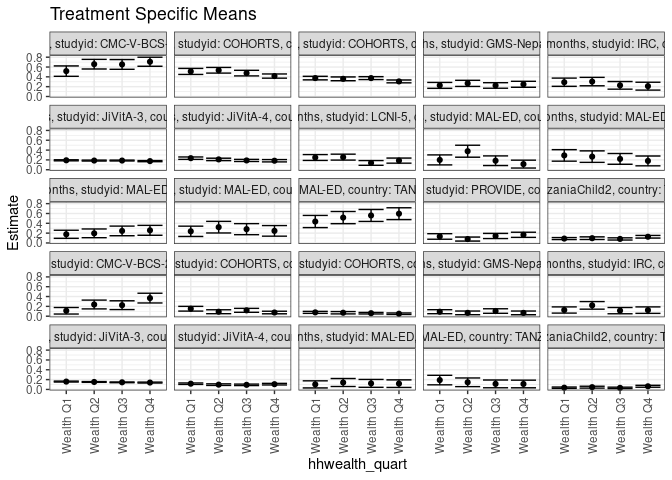

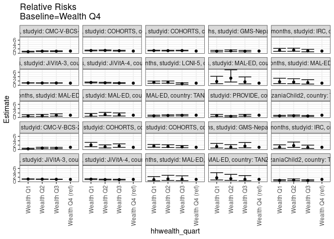

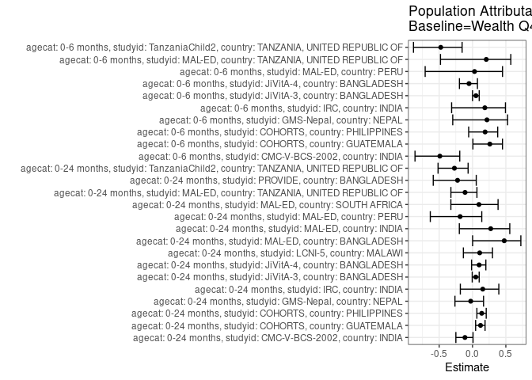

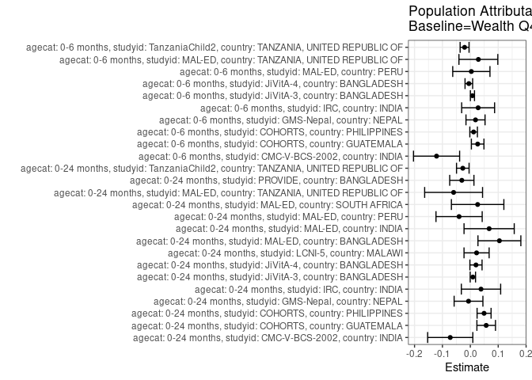

## Results Table

### Parameter: TSM

| agecat | studyid | country | intervention_level | baseline_level | estimate | ci_lower | ci_upper |
| --- | --- | --- | --- | --- | --- | --- | --- |
| 0-24 months | CMC-V-BCS-2002 | INDIA | Wealth Q4 | NA | 0.7074119 | 0.6154605 | 0.7993634 |
| 0-24 months | CMC-V-BCS-2002 | INDIA | Wealth Q1 | NA | 0.5163482 | 0.4107932 | 0.6219033 |
| 0-24 months | CMC-V-BCS-2002 | INDIA | Wealth Q2 | NA | 0.6578304 | 0.5598163 | 0.7558446 |
| 0-24 months | CMC-V-BCS-2002 | INDIA | Wealth Q3 | NA | 0.6529742 | 0.5537867 | 0.7521618 |
| 0-24 months | COHORTS | GUATEMALA | Wealth Q4 | NA | 0.4157382 | 0.3728988 | 0.4585776 |
| 0-24 months | COHORTS | GUATEMALA | Wealth Q1 | NA | 0.5106782 | 0.4494686 | 0.5718879 |
| 0-24 months | COHORTS | GUATEMALA | Wealth Q2 | NA | 0.5336463 | 0.4758986 | 0.5913939 |
| 0-24 months | COHORTS | GUATEMALA | Wealth Q3 | NA | 0.4761689 | 0.4193546 | 0.5329831 |
| 0-24 months | COHORTS | PHILIPPINES | Wealth Q4 | NA | 0.3069092 | 0.2781311 | 0.3356873 |
| 0-24 months | COHORTS | PHILIPPINES | Wealth Q1 | NA | 0.3742977 | 0.3384255 | 0.4101699 |
| 0-24 months | COHORTS | PHILIPPINES | Wealth Q2 | NA | 0.3594648 | 0.3206834 | 0.3982463 |
| 0-24 months | COHORTS | PHILIPPINES | Wealth Q3 | NA | 0.3742665 | 0.3449106 | 0.4036223 |
| 0-24 months | GMS-Nepal | NEPAL | Wealth Q4 | NA | 0.2485969 | 0.1878218 | 0.3093719 |
| 0-24 months | GMS-Nepal | NEPAL | Wealth Q1 | NA | 0.2262113 | 0.1661055 | 0.2863172 |
| 0-24 months | GMS-Nepal | NEPAL | Wealth Q2 | NA | 0.2673258 | 0.2049997 | 0.3296520 |
| 0-24 months | GMS-Nepal | NEPAL | Wealth Q3 | NA | 0.2245398 | 0.1679705 | 0.2811091 |
| 0-24 months | IRC | INDIA | Wealth Q4 | NA | 0.2104904 | 0.1302169 | 0.2907638 |
| 0-24 months | IRC | INDIA | Wealth Q1 | NA | 0.2906431 | 0.2070500 | 0.3742362 |
| 0-24 months | IRC | INDIA | Wealth Q2 | NA | 0.3036612 | 0.2178844 | 0.3894379 |
| 0-24 months | IRC | INDIA | Wealth Q3 | NA | 0.2268242 | 0.1488671 | 0.3047813 |
| 0-24 months | JiVitA-3 | BANGLADESH | Wealth Q4 | NA | 0.1754406 | 0.1639885 | 0.1868927 |
| 0-24 months | JiVitA-3 | BANGLADESH | Wealth Q1 | NA | 0.1919886 | 0.1816295 | 0.2023477 |
| 0-24 months | JiVitA-3 | BANGLADESH | Wealth Q2 | NA | 0.1867636 | 0.1776450 | 0.1958821 |
| 0-24 months | JiVitA-3 | BANGLADESH | Wealth Q3 | NA | 0.1867201 | 0.1782151 | 0.1952250 |
| 0-24 months | JiVitA-4 | BANGLADESH | Wealth Q4 | NA | 0.1832110 | 0.1593064 | 0.2071156 |
| 0-24 months | JiVitA-4 | BANGLADESH | Wealth Q1 | NA | 0.2352402 | 0.2110547 | 0.2594257 |
| 0-24 months | JiVitA-4 | BANGLADESH | Wealth Q2 | NA | 0.2102711 | 0.1860165 | 0.2345256 |
| 0-24 months | JiVitA-4 | BANGLADESH | Wealth Q3 | NA | 0.1890201 | 0.1673282 | 0.2107121 |
| 0-24 months | LCNI-5 | MALAWI | Wealth Q4 | NA | 0.1856525 | 0.1338083 | 0.2374967 |
| 0-24 months | LCNI-5 | MALAWI | Wealth Q1 | NA | 0.2489479 | 0.1890144 | 0.3088814 |

[output cut: 70 more lines]

### Parameter: E(Y)

| agecat | studyid | country | intervention_level | baseline_level | estimate | ci_lower | ci_upper |
| --- | --- | --- | --- | --- | --- | --- | --- |
| 0-24 months | CMC-V-BCS-2002 | INDIA | NA | NA | 0.6353887 | 0.5864772 | 0.6843003 |
| 0-24 months | COHORTS | GUATEMALA | NA | NA | 0.4726135 | 0.4452311 | 0.4999958 |
| 0-24 months | COHORTS | PHILIPPINES | NA | NA | 0.3562316 | 0.3392530 | 0.3732102 |
| 0-24 months | GMS-Nepal | NEPAL | NA | NA | 0.2421203 | 0.2103189 | 0.2739218 |
| 0-24 months | IRC | INDIA | NA | NA | 0.2487805 | 0.2068840 | 0.2906770 |
| 0-24 months | JiVitA-3 | BANGLADESH | NA | NA | 0.1845385 | 0.1789329 | 0.1901441 |
| 0-24 months | JiVitA-4 | BANGLADESH | NA | NA | 0.2034648 | 0.1916516 | 0.2152780 |
| 0-24 months | LCNI-5 | MALAWI | NA | NA | 0.2080783 | 0.1802263 | 0.2359304 |
| 0-24 months | MAL-ED | BANGLADESH | NA | NA | 0.2190083 | 0.1667935 | 0.2712230 |
| 0-24 months | MAL-ED | INDIA | NA | NA | 0.2468085 | 0.1915661 | 0.3020510 |
| 0-24 months | MAL-ED | PERU | NA | NA | 0.2169118 | 0.1678424 | 0.2659811 |
| 0-24 months | MAL-ED | SOUTH AFRICA | NA | NA | 0.2723735 | 0.2178399 | 0.3269072 |
| 0-24 months | MAL-ED | TANZANIA, UNITED REPUBLIC OF | NA | NA | 0.5360000 | 0.4740573 | 0.5979427 |
| 0-24 months | PROVIDE | BANGLADESH | NA | NA | 0.1357143 | 0.1103250 | 0.1611036 |
| 0-24 months | TanzaniaChild2 | TANZANIA, UNITED REPUBLIC OF | NA | NA | 0.0994128 | 0.0873992 | 0.1114263 |
| 0-6 months | CMC-V-BCS-2002 | INDIA | NA | NA | 0.2472826 | 0.2031431 | 0.2914222 |
| 0-6 months | COHORTS | GUATEMALA | NA | NA | 0.1012536 | 0.0828843 | 0.1196229 |
| 0-6 months | COHORTS | PHILIPPINES | NA | NA | 0.0624796 | 0.0538987 | 0.0710604 |
| 0-6 months | GMS-Nepal | NEPAL | NA | NA | 0.0859599 | 0.0651504 | 0.1067694 |
| 0-6 months | IRC | INDIA | NA | NA | 0.1512195 | 0.1164988 | 0.1859402 |
| 0-6 months | JiVitA-3 | BANGLADESH | NA | NA | 0.1474739 | 0.1424227 | 0.1525252 |
| 0-6 months | JiVitA-4 | BANGLADESH | NA | NA | 0.1014266 | 0.0924810 | 0.1103722 |
| 0-6 months | MAL-ED | PERU | NA | NA | 0.1213235 | 0.0824503 | 0.1601967 |
| 0-6 months | MAL-ED | TANZANIA, UNITED REPUBLIC OF | NA | NA | 0.1400000 | 0.0969015 | 0.1830985 |
| 0-6 months | TanzaniaChild2 | TANZANIA, UNITED REPUBLIC OF | NA | NA | 0.0432047 | 0.0350415 | 0.0513679 |

### Parameter: RR

| agecat | studyid | country | intervention_level | baseline_level | estimate | ci_lower | ci_upper |
| --- | --- | --- | --- | --- | --- | --- | --- |
| 0-24 months | CMC-V-BCS-2002 | INDIA | Wealth Q4 | Wealth Q4 | 1.0000000 | 1.0000000 | 1.0000000 |
| 0-24 months | CMC-V-BCS-2002 | INDIA | Wealth Q1 | Wealth Q4 | 0.7299117 | 0.5727830 | 0.9301447 |
| 0-24 months | CMC-V-BCS-2002 | INDIA | Wealth Q2 | Wealth Q4 | 0.9299114 | 0.7631030 | 1.1331829 |
| 0-24 months | CMC-V-BCS-2002 | INDIA | Wealth Q3 | Wealth Q4 | 0.9230467 | 0.7558393 | 1.1272439 |
| 0-24 months | COHORTS | GUATEMALA | Wealth Q4 | Wealth Q4 | 1.0000000 | 1.0000000 | 1.0000000 |
| 0-24 months | COHORTS | GUATEMALA | Wealth Q1 | Wealth Q4 | 1.2283650 | 1.0513708 | 1.4351555 |
| 0-24 months | COHORTS | GUATEMALA | Wealth Q2 | Wealth Q4 | 1.2836114 | 1.1091164 | 1.4855593 |
| 0-24 months | COHORTS | GUATEMALA | Wealth Q3 | Wealth Q4 | 1.1453575 | 0.9811252 | 1.3370810 |
| 0-24 months | COHORTS | PHILIPPINES | Wealth Q4 | Wealth Q4 | 1.0000000 | 1.0000000 | 1.0000000 |
| 0-24 months | COHORTS | PHILIPPINES | Wealth Q1 | Wealth Q4 | 1.2195714 | 1.0695915 | 1.3905818 |
| 0-24 months | COHORTS | PHILIPPINES | Wealth Q2 | Wealth Q4 | 1.1712415 | 1.0185340 | 1.3468443 |
| 0-24 months | COHORTS | PHILIPPINES | Wealth Q3 | Wealth Q4 | 1.2194695 | 1.0827347 | 1.3734721 |
| 0-24 months | GMS-Nepal | NEPAL | Wealth Q4 | Wealth Q4 | 1.0000000 | 1.0000000 | 1.0000000 |
| 0-24 months | GMS-Nepal | NEPAL | Wealth Q1 | Wealth Q4 | 0.9099525 | 0.6387992 | 1.2962031 |
| 0-24 months | GMS-Nepal | NEPAL | Wealth Q2 | Wealth Q4 | 1.0753387 | 0.7719354 | 1.4979924 |
| 0-24 months | GMS-Nepal | NEPAL | Wealth Q3 | Wealth Q4 | 0.9032286 | 0.6414617 | 1.2718169 |
| 0-24 months | IRC | INDIA | Wealth Q4 | Wealth Q4 | 1.0000000 | 1.0000000 | 1.0000000 |
| 0-24 months | IRC | INDIA | Wealth Q1 | Wealth Q4 | 1.3807906 | 0.8590022 | 2.2195318 |
| 0-24 months | IRC | INDIA | Wealth Q2 | Wealth Q4 | 1.4426368 | 0.9007679 | 2.3104741 |
| 0-24 months | IRC | INDIA | Wealth Q3 | Wealth Q4 | 1.0775989 | 0.6478470 | 1.7924285 |
| 0-24 months | JiVitA-3 | BANGLADESH | Wealth Q4 | Wealth Q4 | 1.0000000 | 1.0000000 | 1.0000000 |
| 0-24 months | JiVitA-3 | BANGLADESH | Wealth Q1 | Wealth Q4 | 1.0943227 | 1.0130366 | 1.1821313 |
| 0-24 months | JiVitA-3 | BANGLADESH | Wealth Q2 | Wealth Q4 | 1.0645405 | 0.9895599 | 1.1452025 |
| 0-24 months | JiVitA-3 | BANGLADESH | Wealth Q3 | Wealth Q4 | 1.0642924 | 0.9930695 | 1.1406234 |
| 0-24 months | JiVitA-4 | BANGLADESH | Wealth Q4 | Wealth Q4 | 1.0000000 | 1.0000000 | 1.0000000 |
| 0-24 months | JiVitA-4 | BANGLADESH | Wealth Q1 | Wealth Q4 | 1.2839852 | 1.0942046 | 1.5066816 |
| 0-24 months | JiVitA-4 | BANGLADESH | Wealth Q2 | Wealth Q4 | 1.1476990 | 0.9726576 | 1.3542412 |
| 0-24 months | JiVitA-4 | BANGLADESH | Wealth Q3 | Wealth Q4 | 1.0317075 | 0.8744348 | 1.2172667 |
| 0-24 months | LCNI-5 | MALAWI | Wealth Q4 | Wealth Q4 | 1.0000000 | 1.0000000 | 1.0000000 |
| 0-24 months | LCNI-5 | MALAWI | Wealth Q1 | Wealth Q4 | 1.3409346 | 0.9276444 | 1.9383565 |

[output cut: 70 more lines]

### Parameter: PAR

| agecat | studyid | country | intervention_level | baseline_level | estimate | ci_lower | ci_upper |
| --- | --- | --- | --- | --- | --- | --- | --- |
| 0-24 months | CMC-V-BCS-2002 | INDIA | Wealth Q4 | NA | -0.0720232 | -0.1530186 | 0.0089723 |
| 0-24 months | COHORTS | GUATEMALA | Wealth Q4 | NA | 0.0568753 | 0.0235849 | 0.0901657 |
| 0-24 months | COHORTS | PHILIPPINES | Wealth Q4 | NA | 0.0493224 | 0.0242458 | 0.0743989 |
| 0-24 months | GMS-Nepal | NEPAL | Wealth Q4 | NA | -0.0064765 | -0.0580333 | 0.0450802 |
| 0-24 months | IRC | INDIA | Wealth Q4 | NA | 0.0382901 | -0.0321656 | 0.1087458 |
| 0-24 months | JiVitA-3 | BANGLADESH | Wealth Q4 | NA | 0.0090979 | -0.0005043 | 0.0187001 |
| 0-24 months | JiVitA-4 | BANGLADESH | Wealth Q4 | NA | 0.0202538 | -0.0015533 | 0.0420609 |
| 0-24 months | LCNI-5 | MALAWI | Wealth Q4 | NA | 0.0224258 | -0.0225791 | 0.0674307 |
| 0-24 months | MAL-ED | BANGLADESH | Wealth Q4 | NA | 0.1042542 | 0.0273661 | 0.1811422 |
| 0-24 months | MAL-ED | INDIA | Wealth Q4 | NA | 0.0674550 | -0.0225326 | 0.1574426 |
| 0-24 months | MAL-ED | PERU | Wealth Q4 | NA | -0.0402896 | -0.1231134 | 0.0425341 |
| 0-24 months | MAL-ED | SOUTH AFRICA | Wealth Q4 | NA | 0.0262276 | -0.0678030 | 0.1202582 |
| 0-24 months | MAL-ED | TANZANIA, UNITED REPUBLIC OF | Wealth Q4 | NA | -0.0599416 | -0.1637379 | 0.0438548 |
| 0-24 months | PROVIDE | BANGLADESH | Wealth Q4 | NA | -0.0304696 | -0.0739058 | 0.0129665 |
| 0-24 months | TanzaniaChild2 | TANZANIA, UNITED REPUBLIC OF | Wealth Q4 | NA | -0.0269890 | -0.0494954 | -0.0044827 |
| 0-6 months | CMC-V-BCS-2002 | INDIA | Wealth Q4 | NA | -0.1210307 | -0.2037097 | -0.0383518 |
| 0-6 months | COHORTS | GUATEMALA | Wealth Q4 | NA | 0.0263467 | 0.0038187 | 0.0488747 |
| 0-6 months | COHORTS | PHILIPPINES | Wealth Q4 | NA | 0.0118015 | -0.0017997 | 0.0254027 |
| 0-6 months | GMS-Nepal | NEPAL | Wealth Q4 | NA | 0.0186155 | -0.0155713 | 0.0528023 |
| 0-6 months | IRC | INDIA | Wealth Q4 | NA | 0.0280077 | -0.0310065 | 0.0870218 |
| 0-6 months | JiVitA-3 | BANGLADESH | Wealth Q4 | NA | 0.0076211 | 0.0002485 | 0.0149936 |
| 0-6 months | JiVitA-4 | BANGLADESH | Wealth Q4 | NA | -0.0053029 | -0.0189391 | 0.0083334 |
| 0-6 months | MAL-ED | PERU | Wealth Q4 | NA | 0.0036765 | -0.0630623 | 0.0704152 |
| 0-6 months | MAL-ED | TANZANIA, UNITED REPUBLIC OF | Wealth Q4 | NA | 0.0288889 | -0.0407999 | 0.0985776 |
| 0-6 months | TanzaniaChild2 | TANZANIA, UNITED REPUBLIC OF | Wealth Q4 | NA | -0.0205717 | -0.0365728 | -0.0045706 |

### Parameter: PAF

| agecat | studyid | country | intervention_level | baseline_level | estimate | ci_lower | ci_upper |
| --- | --- | --- | --- | --- | --- | --- | --- |
| 0-24 months | CMC-V-BCS-2002 | INDIA | Wealth Q4 | NA | -0.1133529 | -0.2493576 | 0.0078463 |
| 0-24 months | COHORTS | GUATEMALA | Wealth Q4 | NA | 0.1203420 | 0.0467273 | 0.1882720 |
| 0-24 months | COHORTS | PHILIPPINES | Wealth Q4 | NA | 0.1384559 | 0.0655193 | 0.2056998 |
| 0-24 months | GMS-Nepal | NEPAL | Wealth Q4 | NA | -0.0267492 | -0.2633814 | 0.1655616 |
| 0-24 months | IRC | INDIA | Wealth Q4 | NA | 0.1539113 | -0.1824198 | 0.3945753 |
| 0-24 months | JiVitA-3 | BANGLADESH | Wealth Q4 | NA | 0.0493008 | -0.0043164 | 0.1000556 |
| 0-24 months | JiVitA-4 | BANGLADESH | Wealth Q4 | NA | 0.0995446 | -0.0138967 | 0.2002933 |
| 0-24 months | LCNI-5 | MALAWI | Wealth Q4 | NA | 0.1077758 | -0.1367632 | 0.2997099 |
| 0-24 months | MAL-ED | BANGLADESH | Wealth Q4 | NA | 0.4760285 | 0.0014882 | 0.7250446 |
| 0-24 months | MAL-ED | INDIA | Wealth Q4 | NA | 0.2733091 | -0.1974494 | 0.5589962 |
| 0-24 months | MAL-ED | PERU | Wealth Q4 | NA | -0.1857420 | -0.6330074 | 0.1390216 |
| 0-24 months | MAL-ED | SOUTH AFRICA | Wealth Q4 | NA | 0.0962929 | -0.3243113 | 0.3833122 |
| 0-24 months | MAL-ED | TANZANIA, UNITED REPUBLIC OF | Wealth Q4 | NA | -0.1118313 | -0.3239569 | 0.0663074 |
| 0-24 months | PROVIDE | BANGLADESH | Wealth Q4 | NA | -0.2245131 | -0.5886998 | 0.0561890 |
| 0-24 months | TanzaniaChild2 | TANZANIA, UNITED REPUBLIC OF | Wealth Q4 | NA | -0.2714847 | -0.5166803 | -0.0659290 |
| 0-6 months | CMC-V-BCS-2002 | INDIA | Wealth Q4 | NA | -0.4894430 | -0.8623421 | -0.1912100 |
| 0-6 months | COHORTS | GUATEMALA | Wealth Q4 | NA | 0.2602053 | 0.0059764 | 0.4494132 |
| 0-6 months | COHORTS | PHILIPPINES | Wealth Q4 | NA | 0.1888861 | -0.0574411 | 0.3778322 |
| 0-6 months | GMS-Nepal | NEPAL | Wealth Q4 | NA | 0.2165604 | -0.2964173 | 0.5265586 |
| 0-6 months | IRC | INDIA | Wealth Q4 | NA | 0.1852119 | -0.3130934 | 0.4944155 |
| 0-6 months | JiVitA-3 | BANGLADESH | Wealth Q4 | NA | 0.0516774 | 0.0001895 | 0.1005138 |
| 0-6 months | JiVitA-4 | BANGLADESH | Wealth Q4 | NA | -0.0522826 | -0.1958393 | 0.0740405 |
| 0-6 months | MAL-ED | PERU | Wealth Q4 | NA | 0.0303030 | -0.7099137 | 0.4500821 |
| 0-6 months | MAL-ED | TANZANIA, UNITED REPUBLIC OF | Wealth Q4 | NA | 0.2063492 | -0.4803640 | 0.5745090 |
| 0-6 months | TanzaniaChild2 | TANZANIA, UNITED REPUBLIC OF | Wealth Q4 | NA | -0.4761445 | -0.8849202 | -0.1560184 |